# Practical Machine Learning Course Project

Luis Carlos Wruck

5 de agosto de 2018

## Executive Summary

This is the design required for the completion of the Machine Learning Practical Course. This report is divided into the following parts: 1) Preparation of the environment and installation of the necessary packages 2) Download and clean the data to avoid the use of missing variables (NA). The training base was divided in two (70/30) for the creation of the model and its respective test and measurement of accuracy. 3) A first model using classification tree is created, but the precision is not enough. 4) A final model is created using random forest that calculates 99% accuracy, which is required to obtain 95% confidence to test 20 cases. In order to improve performance, the model was trained using a k-fold = 5 and a ntree = 300. 5) With 99% precision obtained by the model, we predict the 20 cases with 95% confidence required.

## Background

Using devices such as Jawbone Up, Nike FuelBand, and Fitbit it is now possible to collect a large amount of data about personal activity relatively inexpensively. These type of devices are part of the quantified self movement - a group of enthusiasts who take measurements about themselves regularly to improve their health, to find patterns in their behavior, or because they are tech geeks. One thing that people regularly do is quantify how much of a particular activity they do, but they rarely quantify how well they do it. In this project, your goal will be to use data from accelerometers on the belt, forearm, arm, and dumbell of 6 participants. They were asked to perform barbell lifts correctly and incorrectly in 5 different ways. More information is available from the website here: http://groupware.les.inf.puc-rio.br/har (see the section on the Weight Lifting Exercise Dataset).

## Loading required packages

```r
library(rmarkdown)
library(caret)
```

```r
library(rpart)
library(rpart.plot)
library(randomForest)
library(corrplot)
library(rattle)
```

# Downloading data

Downloading the data from the source

```r
pml.training.url <-"https://d396qusza40orc.cloudfront.net/predmachlearn/pml-training.csv"
pml.testing.url <- "https://d396qusza40orc.cloudfront.net/predmachlearn/pml-testing.csv"
pml.training <- "./dados/pml-training.csv"
pml.testing  <- "./dados/pml-testing.csv"
if (!file.exists("./dados")) {
  dir.create("./dados")
}
if (!file.exists(pml.training)) {
  download.file(pml.training.url, destfile=pml.training)
}
if (!file.exists(pml.testing)) {
  download.file(pml.testing.url, destfile=pml.testing)
}
```

## Reading the Data

After downloading the data, we need to read them in two data frames

```r
pml.training <- read.csv("./dados/pml-training.csv",  na.strings = c("NA", "#DIV/0!", ""), header = TRUE)
pml.testing <- read.csv("./dados/pml-testing.csv",  na.strings = c("NA", "#DIV/0!", ""), header = TRUE)

dim(pml.training)
```

```
## [1] 19622   160
```

```r
dim(pml.testing)
```

```
## [1]  20 160
```

## Cleaning Data

```r
pml.training.tp<- pml.training[,colSums(is.na(pml.training)) == 0]
dim(pml.training.tp)
```

```
## [1] 19622    60
```

```r
pml.testing.tp<- pml.testing[,colSums(is.na(pml.testing)) == 0]

training<- pml.training.tp[,-c(1:7)]
testing<- pml.testing.tp[,-c(1:7)]

dim(training)
```

```
## [1] 19622    53
```

```r
dim(testing)
```

```
## [1] 20 53
```

## Correlation Matrix Visualization

We will verify how the variables of the training base are correlated

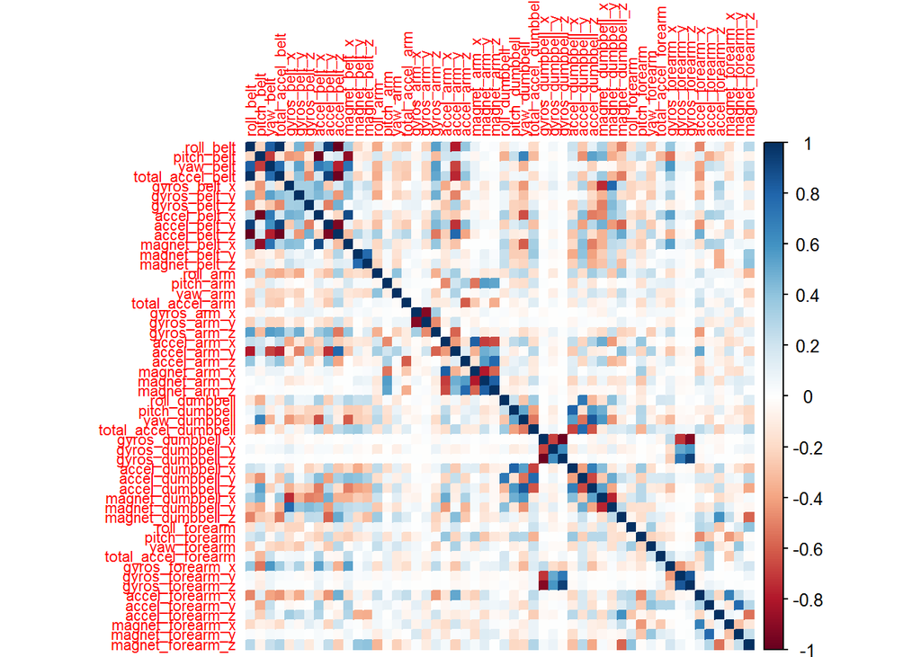

```r
corrPlot <- cor(training[, -length(names(training))])
corrplot(corrPlot, method="color",tl.cex = .7)
```

## Data Partition

Once the data is clear, we will divide the training base into two, training (70%) and validation (30%). We will use the validation base to cross-validate the next steps.

```r
set.seed(1542)
inTrain <- createDataPartition(training$classe, p=0.70, list=F)
train.partition <- training[inTrain, ]
test.partition <- training[-inTrain, ]
```

## Predictive Model using classification trees

Let’s build a first model using the training data.

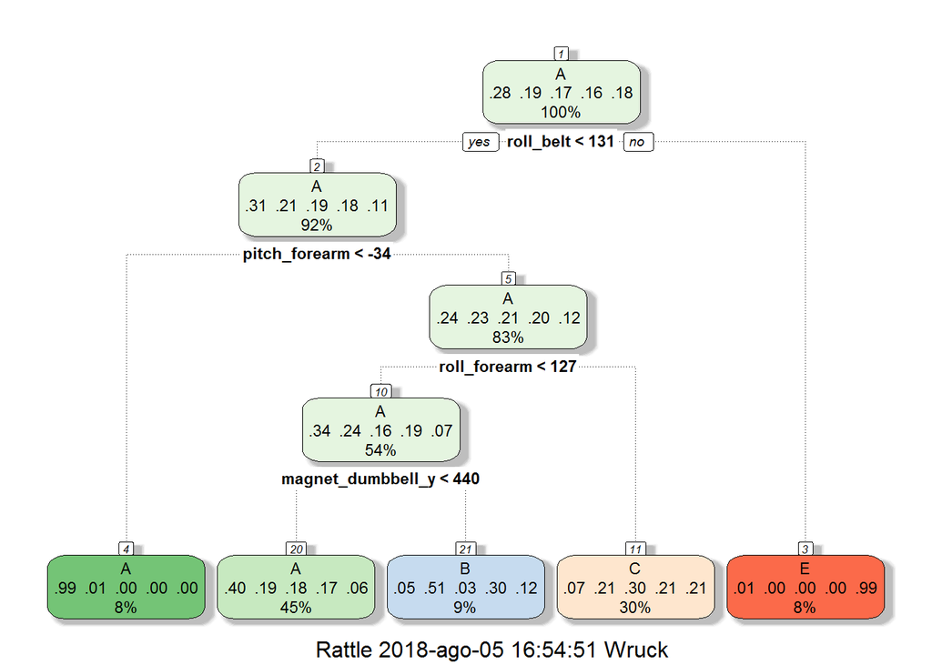

```r
train.partition.ct <- train(classe~., data=train.partition, method="rpart")
fancyRpartPlot(train.partition.ct$finalModel)
```

We predict the values using the test basis and then we calculate the confusion matrix with the results of the accuracy

```r
test.validation.ct<- predict(train.partition.ct, newdata = test.partition)
confusionMatrix(test.validation.ct, test.partition$classe)
```

```
## Confusion Matrix and Statistics
##
##           Reference
## Prediction    A    B    C    D    E
##          A 1528  462  491  440  156
##          B   21  316   15  162   64
##          C  119  361  520  362  380
##          D    0    0    0    0    0
##          E    6    0    0    0  482
##
## Overall Statistics
##
##                Accuracy : 0.4836
##                  95% CI : (0.4708, 0.4965)
##     No Information Rate : 0.2845
##     P-Value [Acc > NIR] : < 2.2e-16
##
##                   Kappa : 0.3253
##  Mcnemar's Test P-Value : NA
##
## Statistics by Class:
##
##                      Class: A Class: B Class: C Class: D Class: E
## Sensitivity            0.9128  0.27744  0.50682   0.0000  0.44547
## Specificity            0.6322  0.94480  0.74851   1.0000  0.99875
## Pos Pred Value         0.4966  0.54671  0.29851      NaN  0.98770
## Neg Pred Value         0.9480  0.84492  0.87787   0.8362  0.88883
## Prevalence             0.2845  0.19354  0.17434   0.1638  0.18386
## Detection Rate         0.2596  0.05370  0.08836   0.0000  0.08190
## Detection Prevalence   0.5229  0.09822  0.29601   0.0000  0.08292
## Balanced Accuracy      0.7725  0.61112  0.62767   0.5000  0.72211
```

## Predictive Model using Random Forest

We fit a predictive model using Random Forest algorithm because it automatically selects important variables and is robust to correlated covariates & outliers in general, improving our model. We will use 5-fold cross validation when applying the algorithm.

```r
controlrf <- trainControl(method="cv", 5)
train.partition.rf <- train(classe ~ ., data=train.partition, method="rf", trControl=controlrf, ntree=300)
train.partition.rf
```

```
## Random Forest
##
## 13737 samples
##    52 predictor
##     5 classes: 'A', 'B', 'C', 'D', 'E'
##
## No pre-processing
## Resampling: Cross-Validated (5 fold)
## Summary of sample sizes: 10990, 10990, 10989, 10990, 10989
## Resampling results across tuning parameters:
##
##   mtry  Accuracy   Kappa
##    2    0.9900996  0.9874753
##   27    0.9900997  0.9874751
##   52    0.9852953  0.9813953
##
## Accuracy was used to select the optimal model using the largest value.
## The final value used for the model was mtry = 27.
```

We will estimate the performance of the model using the validation base

```r
test.validation.rf <- predict(train.partition.rf, newdata = test.partition)
confusionMatrix(test.validation.rf, test.partition$classe)
```

```
## Confusion Matrix and Statistics
##
##           Reference
## Prediction    A    B    C    D    E
##          A 1669   10    0    0    0
##          B    2 1121    1    0    0
##          C    1    8 1018   14    1
##          D    0    0    7  949    4
##          E    2    0    0    1 1077
##
## Overall Statistics
##
##                Accuracy : 0.9913
##                  95% CI : (0.9886, 0.9935)
##     No Information Rate : 0.2845
##     P-Value [Acc > NIR] : < 2.2e-16
##
##                   Kappa : 0.989
##  Mcnemar's Test P-Value : NA
##
## Statistics by Class:
##
##                      Class: A Class: B Class: C Class: D Class: E
## Sensitivity            0.9970   0.9842   0.9922   0.9844   0.9954
## Specificity            0.9976   0.9994   0.9951   0.9978   0.9994
## Pos Pred Value         0.9940   0.9973   0.9770   0.9885   0.9972
## Neg Pred Value         0.9988   0.9962   0.9983   0.9970   0.9990
## Prevalence             0.2845   0.1935   0.1743   0.1638   0.1839
## Detection Rate         0.2836   0.1905   0.1730   0.1613   0.1830
## Detection Prevalence   0.2853   0.1910   0.1771   0.1631   0.1835
## Balanced Accuracy      0.9973   0.9918   0.9936   0.9911   0.9974
```

```r
# estimating accuracy and the estimated out-of-sample error
accuracy <- postResample(test.validation.rf, test.partition$classe)
accuracy
```

```
##  Accuracy     Kappa
## 0.9913339 0.9890379
```

```r
out.of.sample.error <- 1 - as.numeric(confusionMatrix(test.partition$classe, test.validation.rf)$overall[1])
out.of.sample.error
```

```
## [1] 0.0086661
```

The result of accuracy is 99%, which allows us to safely predict the 20 values.

This is the plot of the model error rate by number of trees and 20 most important variables

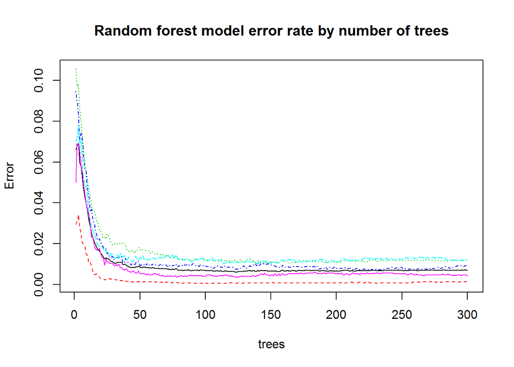

```r
plot(train.partition.rf$finalModel,main="Random forest model error rate by number of trees")
```

```r
varImp(train.partition.rf)
```

```
## rf variable importance
##
##   only 20 most important variables shown (out of 52)
##
##                      Overall
## roll_belt             100.00
## pitch_forearm          58.64
## yaw_belt               54.39
## pitch_belt             46.16
## magnet_dumbbell_z      44.18
## magnet_dumbbell_y      42.55
## roll_forearm           41.74
## accel_dumbbell_y       22.77
## magnet_dumbbell_x      18.63
## accel_forearm_x        17.97
## roll_dumbbell          17.84
## magnet_belt_z          16.21
## accel_belt_z           14.94
## accel_dumbbell_z       14.50
## magnet_forearm_z       13.73
## total_accel_dumbbell   12.39
## magnet_belt_y          12.18
## yaw_arm                11.20
## magnet_belt_x          11.13
## gyros_belt_z           10.63
```

## Predicting for Test Data Set

Once we have our random forest model performing, we can use it to predict how people will exercise. The final results were saved in a archive.

```r
predict_test<- predict(train.partition.rf, testing)
predict_test
```

```
##  [1] B A B A A E D B A A B C B A E E A B B B
## Levels: A B C D E
```

```r
write.csv(predict_test,"./dados/result.csv")
```